dgtrabada

- .rst

# Cuestionario gestión de memoria

# Cuestionario gestión de memoria

1. Responde:

1. ¿Un 1GB de memoria RAM es más caro que 1GB de disco duro?

Sí No

2. ¿Qué sistema de particiones favorece más la fragmentación interna, las fijas o las dinámicas?

Fijas Dinámicas

3. Fíjate en la siguiente tabla de páginas: un proceso quiere acceder a la dirección D0000, ¿está en la memoria principal o en la memoria secundaria?

Tabla de páginas

| Dir. virtual | Bit de presencia | Dir. física |
| --- | --- | --- |
| 10000 | 1 | 10000 |
| 20000 | 0 | 10000 |
| 30000 | 1 | 40000 |
| 80000 | 1 | 60000 |
| D0000 | 0 | 60000 |

En la memoria secundaria En la memoria principal

4. Fíjate en la tabla de páginas anterior: un proceso quiere acceder a la dirección 30000, ¿está en la memoria principal o en la memoria secundaria?

En la memoria secundaria En la memoria principal

5. Fíjate en la siguiente memoria virtual y rellena la tabla de páginas:

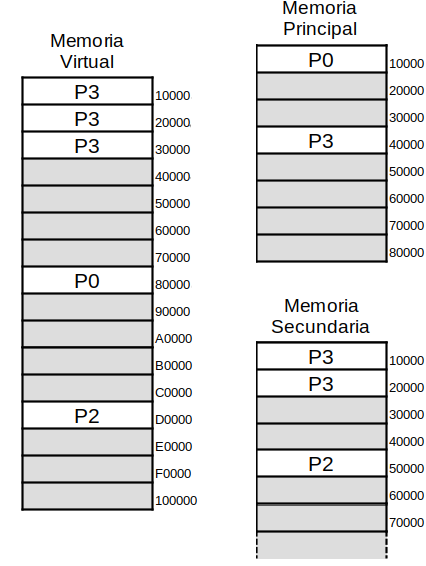

| Dir. virtual | Bit de presencia | Dir. física |
| --- | --- | --- |
| 10000 | 0 |  |
| 20000 | 0 |  |
| 30000 |  | 40000 |
|  | 1 |  |

6. ¿Qué algoritmo de reemplazo puede dar más fallos al aumentar el número de marcos (anomalía de Belady)?

FIFO LRU Óptimo

6. En la cola se han almacenado, por orden de llegada, las siguientes peticiones de pistas: **20,32,50,2,95**. Inicialmente la cabeza de lectura/escritura está en la **pista 49** y el disco tiene las **pistas de 0 a 99**.  
Responde con las pistas separadas por coma y sin espacios, por ejemplo: 20,32,... Fíjate en el rango de pistas del disco de cada ejercicio. En SCAN y C-SCAN la cabeza llega hasta el extremo del disco, y el salto de vuelta de C-SCAN cuenta en el total.

1. ¿Cómo atendería las peticiones con FIFO?

Total de pistas recorridas:

2. ¿Cómo atendería las peticiones con SSTF?

Total de pistas recorridas:

3. ¿Cómo atendería las peticiones con SCAN? "primero sube hasta el final"

Total de pistas recorridas:

4. ¿Cómo atendería las peticiones con C-SCAN? "primero sube, llega al final, salta al principio y va leyendo subiendo"

Total de pistas recorridas:

7. En la cola se han almacenado, por orden de llegada, las siguientes peticiones de pistas: **20,8,5,18,13**. Inicialmente la cabeza de lectura/escritura está en la **pista 17** y el disco tiene las **pistas de 0 a 99**.  
Responde con las pistas separadas por coma y sin espacios, por ejemplo: 20,32,... Fíjate en el rango de pistas del disco de cada ejercicio. En SCAN y C-SCAN la cabeza llega hasta el extremo del disco, y el salto de vuelta de C-SCAN cuenta en el total.

1. ¿Cómo atendería las peticiones con FIFO?

Total de pistas recorridas:

2. ¿Cómo atendería las peticiones con SSTF?

Total de pistas recorridas:

3. ¿Cómo atendería las peticiones con SCAN? "primero baja hasta el principio"

Total de pistas recorridas:

4. ¿Cómo atendería las peticiones con C-SCAN? "primero baja, llega al principio, salta al final y va leyendo bajando"

Total de pistas recorridas:

5. ¿Cuál sería el algoritmo más rápido en atender las peticiones (FIFO, SSTF, SCAN o C-SCAN)?

8. En la cola se han almacenado, por orden de llegada, las siguientes peticiones de pistas: **10,70,45,90,25**. Inicialmente la cabeza de lectura/escritura está en la **pista 40** y el disco tiene las **pistas de 0 a 99**.  
Responde con las pistas separadas por coma y sin espacios, por ejemplo: 20,32,... Fíjate en el rango de pistas del disco de cada ejercicio. En SCAN y C-SCAN la cabeza llega hasta el extremo del disco, y el salto de vuelta de C-SCAN cuenta en el total.

1. ¿Cómo atendería las peticiones con FIFO?

Total de pistas recorridas:

2. ¿Cómo atendería las peticiones con SSTF?

Total de pistas recorridas:

3. ¿Cómo atendería las peticiones con SCAN? "primero sube hasta el final"

Total de pistas recorridas:

4. ¿Cómo atendería las peticiones con C-SCAN? "primero sube, llega al final, salta al principio y va leyendo subiendo"

Total de pistas recorridas:

5. ¿Cuál sería el algoritmo más rápido en atender las peticiones (FIFO, SSTF, SCAN o C-SCAN)?

9. En la cola se han almacenado, por orden de llegada, las siguientes peticiones de pistas: **20,35,8,28,4**. Inicialmente la cabeza de lectura/escritura está en la **pista 18** y el disco tiene las **pistas de 0 a 99**.  
Responde con las pistas separadas por coma y sin espacios, por ejemplo: 20,32,... Fíjate en el rango de pistas del disco de cada ejercicio. En SCAN y C-SCAN la cabeza llega hasta el extremo del disco, y el salto de vuelta de C-SCAN cuenta en el total.

1. ¿Cómo atendería las peticiones con FIFO?

Total de pistas recorridas:

2. ¿Cómo atendería las peticiones con SSTF?

Total de pistas recorridas:

3. ¿Cómo atendería las peticiones con SCAN? "primero baja hasta el principio"

Total de pistas recorridas:

4. ¿Cómo atendería las peticiones con C-SCAN? "primero baja, llega al principio, salta al final y va leyendo bajando"

Total de pistas recorridas:

5. ¿Cuál sería el algoritmo más rápido en atender las peticiones (FIFO, SSTF, SCAN o C-SCAN)?